# Data visualization with ggplot2

## ggplot2

No we’re going to introduce a data visualization package called **ggplot2**. This package is great for producing publication quality graphics, but the syntax used in plotting can be a bit tricky.

First, recall how to install and load packages. Install the package if you haven’t already:

```r
# Only need to do this once
install.packages("ggplot2")
```

Then load it:

```r
library(ggplot2)
```

Let’s retun to the iris dataset, using the dataset we created that includes habitat type.

```r
iris_habitat <- data.frame( Species = c( "setosa", "versicolor", "virginica" ),
                            Habitat = c( "forest", "wetland", "meadow" ) )

iris_full <- merge( x = iris, y = iris_habitat, by = "Species" )

head( iris_full )
```

```
##   Species Sepal.Length Sepal.Width Petal.Length Petal.Width Habitat
## 1  setosa          5.1         3.5          1.4         0.2  forest
## 2  setosa          4.9         3.0          1.4         0.2  forest
## 3  setosa          4.7         3.2          1.3         0.2  forest
## 4  setosa          4.6         3.1          1.5         0.2  forest
## 5  setosa          5.0         3.6          1.4         0.2  forest
## 6  setosa          5.4         3.9          1.7         0.4  forest
```

```r
tail( iris_full )
```

```
##       Species Sepal.Length Sepal.Width Petal.Length Petal.Width Habitat
## 145 virginica          6.7         3.3          5.7         2.5  meadow
## 146 virginica          6.7         3.0          5.2         2.3  meadow
## 147 virginica          6.3         2.5          5.0         1.9  meadow
## 148 virginica          6.5         3.0          5.2         2.0  meadow
## 149 virginica          6.2         3.4          5.4         2.3  meadow
## 150 virginica          5.9         3.0          5.1         1.8  meadow
```

We would like to plot Sepal.Length versus Petal.Length. We’ll first do this using **base R** functions.

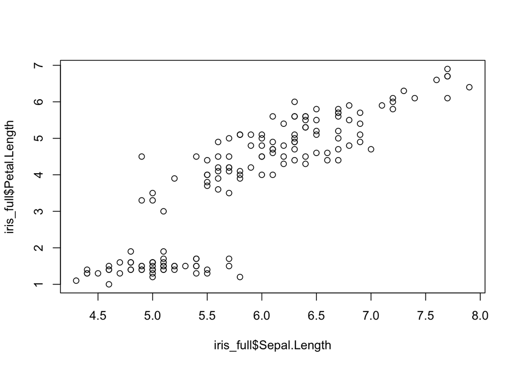

```r
plot( x = iris_full$Sepal.Length, y = iris_full$Petal.Length )
```

Note, we could save a little typing by using the `with` function. This sets up a temporary environment where all of the variables (columns) in my dataset are defined individually.

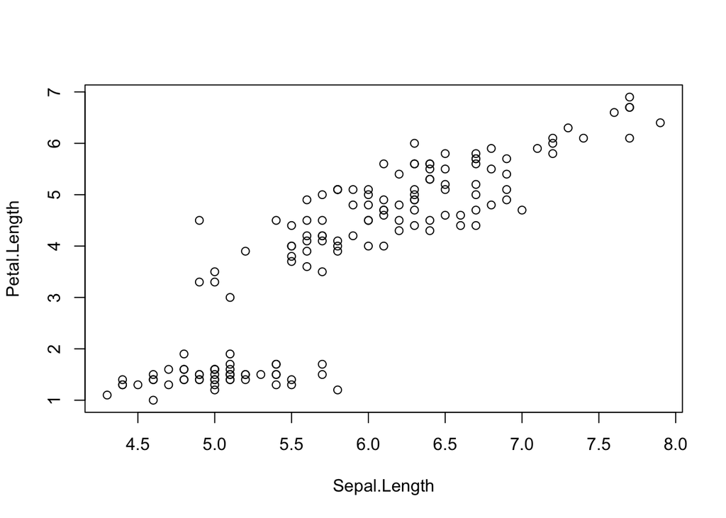

```r
with( data = iris_full, plot( x = Sepal.Length, y = Petal.Length ) )
```

OK, let’s fire up ggplot.

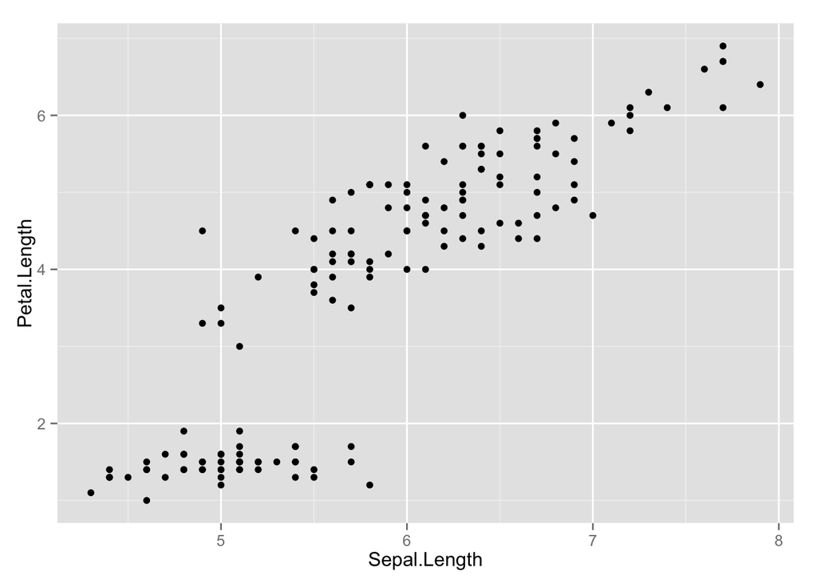

```r
ggplot() + # First make an empty ggplot canvas. Notice the trailing plus sign
  geom_point( data = iris_full, aes( x = Sepal.Length, y = Petal.Length ) )
```

Let’s break down that call to introduce a few key things about ggplot

- ggplot: the initial canvas we’re working on
- geom: geometric objects (i.e. the type of plot - histogram, points, line, etc)
- aes: aesthetic mapping

**THAT SEEMS SO COMPLICATED!**

It’s true, for simple plots, ggplot can be much more complicated than simply using the base functions. But the power of ggplot lies in the ability to lay several geometries (geoms) over each other. Also, each geometry has a rich set of options. For example, let’s say I want to create the plot we just made, but have each species represented by a different color.

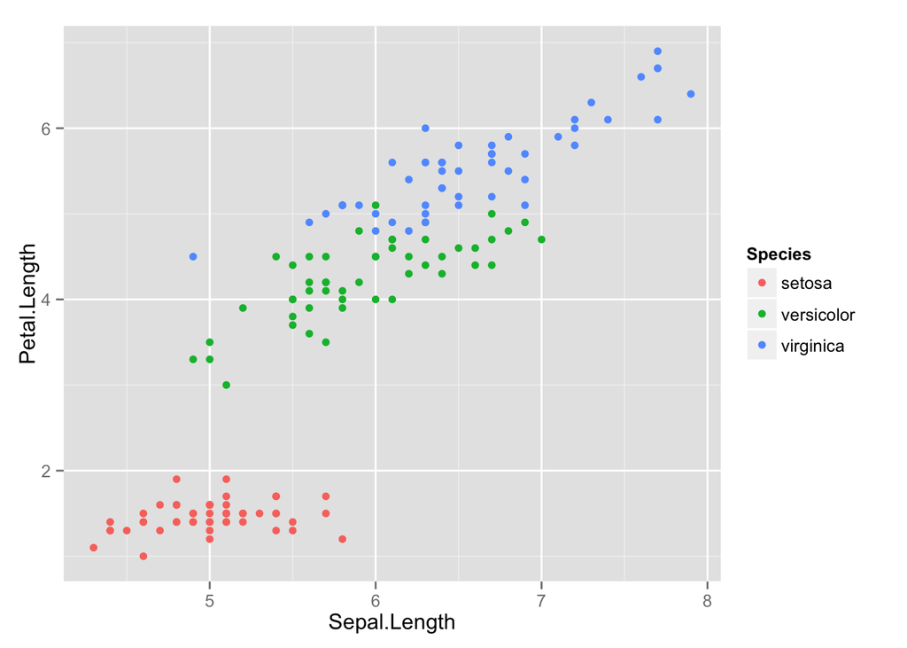

```r
ggplot() + # First make an empty ggplot canvas. Notice the trailing plus sign
  geom_point( data = iris_full, aes( x = Sepal.Length, y = Petal.Length, colour = Species ) )
```

**facets** - a way to seperate data into different subplots

Let’s say we wanted different plots for each species. We can do that in ggplot using `facets`.

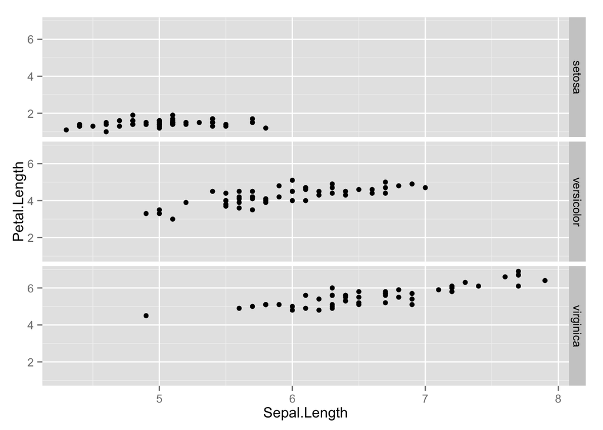

```r
ggplot( data = iris_full, aes( x = Sepal.Length, y = Petal.Length ) ) +
  geom_point() +
  facet_grid( Species ~ . )
```

**NOTE**: I moved the `data ...` stuff into the initial `ggplot` call here.

# Challange

ggplot has many geometries, allowing us to make lot’s of different types of plots. Let’s make two new plots - one boxplot of Sepal.Length, with one boxplot for each species. Use `geom_boxplot` for this. Second, let’s make density plots of Sepal.Width. Use `geom_density` and `colour` to make different coloured density lines for iris in each habitat type.

## Further **ggplot2** resources

- http://docs.ggplot2.org/current/: The official **ggplot2** documentation.
- http://www.amazon.com/o/ASIN/0387981403/ref=nosim/gettgenedone-20: The **ggplot2** book, by the developer, Hadley Wickham.
- https://groups.google.com/forum/#!forum/ggplot2: The **ggplot2** Google Group (mailing list, discussion forum).
- https://github.com/swcarpentry/bc/tree/master/intermediate/r/data-visualization: Intermediate Software Carpentry lesson on data visualization with **ggplot2**.
- http://learnr.wordpress.com/: A blog with a good number of posts describing how to reproduce various kind of plots using **ggplot2**.
- http://stackoverflow.com/questions/tagged/ggplot2: Thousands of questions and answers tagged with “ggplot2” on Stack Overflow, a programming Q&A site.